# Extending WAASB package

Examples with code and outputs

Tiago Olivoto

WAASB 1.0.1 2018-10-06

# 1 Introducing the `WAASB` R package

The WAASB R package was developed in R language and is distributed under the GPL 3.0 licence. Our main motivation for the package development was to provide friendly, easy and reliable functions provide de singular value decomposition of BLUP-interaction effects matrix as weel as to share codes used for traditional AMMI analysis and BLUP prediction. The package can be downloaded by clicking [here](https://github.com/TiagoOlivoto/WAASB/archive/master.zip) or running the following code in the R console:

## 1.1 Overview of the `WAASB` package.

> Package `WAASB` available at `github`. Installation

```r
# download the package from Github
devtools::install_github("TiagoOlivoto/WAASB")
```

## 1.2 Main functions of `WAASB` package.

| Functions | Description |
| --- | --- |
| `performs_ammi()` | Performs Additive Main effects and Multiplicative Interaction |
| `plot.eigen()` | Plot the eigenvalues of singular value decomposition |
| `plot.blup()` | Plot the estimated BLUPs of genotypes |
| `plot.validation.AMMIF()` | Plot the RMSE of all AMMI-family tested models |
| `plot.WAASBY()` | Plot WAASBY values for genotype ranking |
| `plot.WAASBYratio()` | Plot heat maps with genotype ranking |
| `predict.WAAS.AMMI()` | Predict the means of a `WAAS.AMMI` object |
| `summary.WAASB()` | Summary a WAASB object |
| `theme_waasb()` | A personalized theme for the WAASB ggplot2-based graphics |
| `validation.blup()` | Cross-validation for blup prediction |
| `validation.AMMIF()` | BLUP-interaction effects matrix in different scenarios of WAASB/GY ratio |
| `WAASBYratio()` | BLUP-interaction effects matrix in different scenarios of WAASB/GY ratio |
| `WAAS.AMMI()` | Weighted Average of Absolute Scores for AMMI analysis |
| `WAASratio.AMMI()` | Weighted Average of Absolute Scores for AMMI analysis in different scenarios of WAAS/GY ratio |
| `WAASB()` | Weighted Average of Absolute Scores for BLUP-based PCA analysis |

# 2 Getting started

A data set with data on 10 oat genotypes conducted in 16 environments is provided to make reproducible examples. This data is available in Olivoto (2018). An own data set can be used provided that the columns are in the following order: environment, genotype, block/replicate and response variable(s).

```r
# Importing data
require(WAASB)
dataset = read.csv("https://data.mendeley.com/datasets/2sjz32k3s3/1/files/07764a07-172a-4285-85db-c31bc39ae480/WAASBdata.csv?dl=1")
```

# 3 Predictive accuracy

The functions `validation.AMMIF` provides a complete cross-validation for AMMI model family using replicate-based data. Automatically the first validation is carried out considering the AMMIF model (all possible axis is used). Considering this model, the original data set is split into two data sets: modelling and validating data. The “modelling” data set has all combinations (genotype x environment) with the number of replications informed in the argument `nrepval`. The data set “validating” has one replication. The splitting of the data set into modelling and validating data depends on the design informed. For Completely Randomized Block Design (default), completely blocks are selected within environments, as suggested by Piepho (1994). The remained block serves as validation data. If `design = "RCD"` is informed, thus declaring that the a completely randomized design was used, single observations are randomized for each treatment (genotype-by-environment combination). This is the same procedure suggested by Gauch and Zobel (1988). The estimated values (for each AMMI model family) are compared with the “validating” data. the Root Means Square Prediction Difference is computed according to the following equation:

$$RMSPD =
\sqrt{\frac{\sum_{i = 1}^n(\widehat{y}_{ij}-y_{ij})^2} {n}}$$

where $\widehat{y}_{ij}$ is the model predicted value; and $y_{ij}$ is the observed value of the validating data set. At the end of boots, a list with all estimated RMSE and the average of RMSE is returned.

The function `validation.blup` provides a cross-validation of replicate-based data using mixed models. By default, complete blocks are randomly selected each environment. The procedure for computing the RSME is identical to the above function.

```r
# cross-validation for AMMI model family
AMMIweat = validation.AMMIF(dataset,
                            resp = GY,
                            gen = GEN,
                            env = ENV,
                            rep = BLOCK,
                            nboot = 100,
                            nrepval = 2)

# cross-validation for BLUP model
BLUPweat = validation.blup(dataset,
                            resp = GY,
                            gen = GEN,
                            env = ENV,
                            rep = BLOCK,
                            nboot = 100,
                            nrepval = 2)
```

A progress bar is shown by default (the examples are bellow). Thus, it is possible to verify the status of the cross-validation process. If necessary, the progress bar can be disabled by informing the argument `progbar = FALSE` in the function.

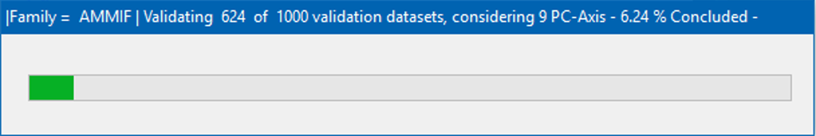

Progress bar for AMMI model family cross-validation process.

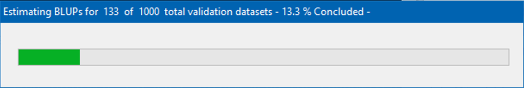

Progress bar for BLUP cross-validation process.

## 3.1 Printting the means of RMSE estimates

```r
options(digits = 4)
RMSEweat = rbind(AMMIweat$RMSPDmean, BLUPweat$RMSPDmean)
RMSEweat = dplyr::mutate(RMSEweat, CROP = "Wheat")
RMSEweat = RMSEweat[order(RMSEweat[,2], decreasing = F),]
#print(RMSEweat)
```

|  | MODEL | mean | CROP |
| --- | --- | --- | --- |
| 11 | BLUP | 0.4081 | Wheat |
| 1 | AMMI3 | 0.4201 | Wheat |
| 2 | AMMI2 | 0.4232 | Wheat |
| 3 | AMMI4 | 0.4235 | Wheat |
| 4 | AMMI5 | 0.4271 | Wheat |
| 5 | AMMI6 | 0.4292 | Wheat |
| 6 | AMMI7 | 0.4321 | Wheat |
| 7 | AMMI8 | 0.4331 | Wheat |
| 8 | AMMIF | 0.4332 | Wheat |
| 9 | AMMI0 | 0.4384 | Wheat |
| 10 | AMMI1 | 0.4399 | Wheat |

The results shown above are the mean of 100 RMSE estimates for each tested model and are presented from the most accurate model (smallest RSME value) to the lowest accurate model (highest RMSE value).

## 3.2 Plotting the RMSPD values

> It is also possible plotting the RMSPD values in a boxplot graphic. Let’s to do it.

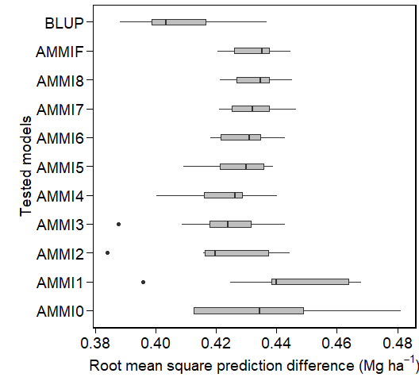

```r
# binding AMMI and BLUP RMSEs
RMSPDweat = list(RMSPD = rbind(AMMIweat$RMSPD,
                           BLUPweat$RMSPD))
# Plotting the RMSPD values
plot.validation.AMMIF(RMSPDweat,
                      violin = FALSE,
                      col.boxplot = "gray75")
```

Five statistics are shown in this boxplot. The median, the lower and upper hinges correspond to the first and third quartiles (the 25th and 75th percentiles, respectively). The upper whisker extends from the hinge to the largest value no further than $1.5\times{IQR}$ from the hinge (where IQR is the inter-quartile range). The lower whisker extends from the hinge to the smallest value at most $1.5\times{IQR}$ of the hinge. Data beyond the end of the whiskers are considered outlying points. If the condition `violin = TRUE`, a violin plot is added joint with the boxplot. A violin plot is a compact display of a continuous distribution displayed in the same way as a boxplot.

# 4 Predicting the yield by traditional AMMI model using replicate-based data

The function `predict.AMMI` (or the generic function `predict()`) can be used to predict the response variable of a two-way table (for example, the yielding of the *i*th genotype in the *j*th environment) based on the traditional AMMI model. This prediction is based on the number of multiplicative terms used. If `naxis = 0`, only the main effects (AMMI0) are used. In this case, the predicted mean will be the predicted value from OLS estimation. If `naxis = 1` the AMMI1 (with one multiplicative term) is used for predicting the response variable. If `naxis = min(gen-1;env-1)`, the AMMIF is fitted and the predicted value will be the cell mean, i.e., the mean of R replicates of the *i*th genotype in the *j*th environment. The number of axes to be used must be carefully chosen. Procedures based on postdictive success (such as Gollobs’s d.f.) or predictive success (such as cross-validation) should be used to do this. This package provides both. `WAAS.AMMI` function compute traditional AMMI analysis showing the number of significant axes. On the other hand, `validation.AMMIF` function provides a cross-validation, estimating the RMSE of all AMMI model family based on re-sampling procedures.

> Predicting the yield of 10 oat cultivars in 16 environments using 5 multiplicative terms.

```r
model =  WAAS.AMMI(dataset,
                   resp = GY,
                   gen = GEN,
                   env = ENV,
                   rep = BLOCK)
predictoat = predict(model, naxis = 5)
```

| ENV | GEN | Y | resOLS | Ypred | ResAMMI | YpredAMMI | AMMI0 |
| --- | --- | --- | --- | --- | --- | --- | --- |
| CF2010 | G1 | 2.366 | -0.0878 | 2.454 | 0.04956 | 2.503 | 2.454 |
| CF2010 | G10 | 1.974 | -0.3620 | 2.336 | -0.35636 | 1.980 | 2.336 |
| CF2010 | G2 | 2.902 | 0.3694 | 2.533 | 0.37700 | 2.910 | 2.533 |
| CF2010 | G3 | 2.888 | 0.1175 | 2.771 | 0.03069 | 2.801 | 2.771 |
| CF2010 | G4 | 2.589 | 0.0618 | 2.527 | -0.05530 | 2.472 | 2.527 |
| CF2010 | G5 | 2.189 | -0.2068 | 2.395 | -0.09272 | 2.303 | 2.395 |
| CF2010 | G6 | 2.301 | -0.0785 | 2.379 | -0.06152 | 2.318 | 2.379 |
| CF2010 | G7 | 2.774 | 0.2337 | 2.540 | 0.22216 | 2.762 | 2.540 |
| CF2010 | G8 | 2.899 | 0.0302 | 2.869 | -0.01589 | 2.853 | 2.869 |
| CF2010 | G9 | 2.326 | -0.0776 | 2.404 | -0.09762 | 2.306 | 2.404 |

Only the first ten values are shown. The following values are presented: **ENV** is the environment; **GEN** is the genotype; **Y** is the response variable; **resOLS** is the residual ($\hat{z}_{ij}$) estimated by the Ordinary Least Square (OLS), where $\hat{z}_{ij} = y_{ij} - \bar{y}_{i.} - \bar{y}_{.j} + \bar{y}_{ij}$; **Ypred** is the predicted value by OLS ($\hat{y}_{ij} = y_{ij} -\hat{z}_{ij}$); **ResAMMI** is the residual estimated by the AMMI model ($\hat{a}_{ij}$) considering the number of multiplicative terms informed in the function (in this case 5), where $\hat{a}_{ij} = \lambda_1\alpha_{i1}\tau_{j1}+...+\lambda_5\alpha_{i5}\tau_{j5}$; **YpredAMMI** is the predicted value by AMMI model $\hat{ya}_{ij} = \bar{y}_{i.} + \bar{y}_{.j} - \bar{y}_{ij}+\hat{a}_{ij}$; and **AMMI0** is the predicted value when no multiplicative terms are used, i.e., $\hat{y}_{ij} = \bar{y}_{i.} + \bar{y}_{.j} - \bar{y}_{ij}$.

# 5 Estimating the WAAS (based on traditional AMMI model)

The `WAAS.AMMI` function compute the weighted average of absolute scores considering: (i) all principal component axes that are significant at a given probability error level; or (ii) declaring a specific number of axes to be used, according to the following equation:

$$WAAS_i =
\sum_{k = 1}^{s} |PCA_{ik} \times EP_k|/ \sum_{k = 1}^{s}EP_k$$

where $WAAS_i$ is the weighted average of absolute scores of the *i*th genotype; $PCA_{ik}$ is the score of the *i*th genotype in the *k*th PCA; and $EP_k$ is the explained variance of the *k*th PCA for $k = 1,2,..,s$, considering *s* the number of significant PCA, or a a declared number of PCA. The following functions can be used to do this.

## 5.1 Assuming a given probability error for chosing the number of axes

In this example only PCA with *P*-value $\le$ 0.05 will be used in the WAAS estimation.

```r
library(WAASB)
# Assuming equal weights for productivity and stability
WAAS1 = WAAS.AMMI(dataset,
                  resp = GY,
                  gen = GEN,
                  env = ENV,
                  rep = BLOCK,
                  p.valuePC = 0.05,
                  weight.response = 50,
                  weight.WAAS = 50)

# Priorizing productivity for genotype ranking (WAASB/GY ratio = 30/70)
# no output for this script
WAAS11 = WAAS.AMMI(dataset,
                  resp = GY,
                  gen = GEN,
                  env = ENV,
                  rep = BLOCK,
                  p.valuePC = 0.05,
                  weight.response = 70,
                  weight.WAAS = 30)
```

```r
options (digits = 4)
# printing the WAASB object
print(WAAS1$anova)
```

|  | Df | Sum Sq | Mean Sq | F value | Pr(>F) | Percent | Accumul |
| --- | --- | --- | --- | --- | --- | --- | --- |
| ENV | 15 | 285.9097 | 19.0606 | 60.239 | 0.0000000000000000000000 | . | . |
| REP(ENV) | 32 | 10.1253 | 0.3164 | 3.066 | 0.0000003177891856598596 | . | . |
| GEN | 9 | 13.0837 | 1.4537 | 14.085 | 0.0000000000000000008381 | . | . |
| ENV:GEN | 135 | 39.7552 | 0.2945 | 2.853 | 0.0000000000000563937810 | . | . |
| PC1 | 23 | 13.0618 | 0.5679 | 5.500 | 0.0000000000000000000000 | 32.9 | 32.9 |
| PC2 | 21 | 10.6865 | 0.5089 | 4.930 | 0.0000000000000000000000 | 26.9 | 59.7 |
| PC3 | 19 | 6.8031 | 0.3581 | 3.470 | 0.0000000000000000000000 | 17.1 | 76.8 |
| PC4 | 17 | 3.6847 | 0.2168 | 2.100 | 0.0071999999999999998029 | 9.3 | 86.1 |
| PC5 | 15 | 2.6701 | 0.1780 | 1.720 | 0.0466000000000000025313 | 6.7 | 92.8 |
| PC6 | 13 | 1.4540 | 0.1118 | 1.080 | 0.3760999999999999898748 | 3.7 | 96.5 |
| PC7 | 11 | 0.7266 | 0.0660 | 0.640 | 0.7939000000000000500933 | 1.8 | 98.3 |
| PC8 | 9 | 0.4652 | 0.0517 | 0.500 | 0.8739999999999999991118 | 1.2 | 99.5 |
| PC9 | 7 | 0.2032 | 0.0290 | 0.280 | 0.9615000000000000213163 | 0.5 | 100 |
| Residuals | 288 | 29.7248 | 0.1032 | NA | NA | . | . |
| Total | 479 | 378.5987 | 0.7904 | NA | NA | . | . |

> printing the WAASB object

```r
options (digits = 4)
print(WAAS1$model[, c(1:3,13:17, 21:22)])
```

| type | Code | Y | WAAS | PctResp | PctWAAS | OrResp | OrWAAS | WAASY | OrWAASY |
| --- | --- | --- | --- | --- | --- | --- | --- | --- | --- |
| GEN | G1 | 2.624 | 0.1778 | 86.32 | 99.00 | 6 | 1 | 92.66 | 6 |
| GEN | G10 | 2.506 | 0.5003 | 82.46 | 97.19 | 10 | 10 | 89.82 | 10 |
| GEN | G2 | 2.703 | 0.3124 | 88.93 | 98.24 | 4 | 6 | 93.59 | 3 |
| GEN | G3 | 2.941 | 0.2037 | 96.77 | 98.85 | 2 | 2 | 97.81 | 2 |
| GEN | G4 | 2.697 | 0.3682 | 88.74 | 97.93 | 5 | 7 | 93.33 | 5 |
| GEN | G5 | 2.566 | 0.2143 | 84.41 | 98.79 | 8 | 3 | 91.60 | 7 |
| GEN | G6 | 2.549 | 0.2439 | 83.88 | 98.63 | 9 | 4 | 91.25 | 8 |
| GEN | G7 | 2.710 | 0.3843 | 89.17 | 97.84 | 3 | 8 | 93.50 | 4 |
| GEN | G8 | 3.039 | 0.2465 | 100.00 | 98.61 | 1 | 5 | 99.31 | 1 |
| GEN | G9 | 2.574 | 0.4473 | 84.68 | 97.48 | 7 | 9 | 91.08 | 9 |
| ENV | CF2010 | 2.521 | 0.1787 | 62.02 | 98.47 | 10 | 6 | 80.24 | 9 |
| ENV | CF2011 | 3.180 | 0.2086 | 78.24 | 98.21 | 4 | 7 | 88.22 | 4 |
| ENV | CF2012 | 4.064 | 0.3627 | 100.00 | 96.89 | 1 | 15 | 98.44 | 1 |
| ENV | CF2013 | 3.675 | 0.2564 | 90.43 | 97.80 | 3 | 11 | 94.11 | 3 |
| ENV | CF2014 | 2.507 | 0.2429 | 61.69 | 97.91 | 11 | 10 | 79.80 | 11 |
| ENV | CF2015 | 3.107 | 0.3486 | 76.45 | 97.01 | 5 | 14 | 86.73 | 5 |
| ENV | CF2016 | 3.910 | 0.2115 | 96.22 | 98.18 | 2 | 8 | 97.20 | 2 |
| ENV | CF2017 | 2.663 | 0.1167 | 65.53 | 99.00 | 8 | 2 | 82.26 | 8 |
| ENV | SF2010 | 1.989 | 0.2973 | 48.94 | 97.45 | 13 | 12 | 73.19 | 13 |
| ENV | SF2011 | 2.536 | 0.2263 | 62.41 | 98.06 | 9 | 9 | 80.23 | 10 |
| ENV | SF2012 | 3.057 | 0.4128 | 75.21 | 96.45 | 6 | 16 | 85.83 | 6 |
| ENV | SF2013 | 2.175 | 0.1623 | 53.52 | 98.61 | 12 | 4 | 76.06 | 12 |
| ENV | SF2014 | 1.368 | 0.1164 | 33.66 | 99.00 | 16 | 1 | 66.33 | 16 |
| ENV | SF2015 | 1.609 | 0.1663 | 39.58 | 98.57 | 15 | 5 | 69.07 | 15 |
| ENV | SF2016 | 2.910 | 0.3235 | 71.59 | 97.22 | 7 | 13 | 84.41 | 7 |
| ENV | SF2017 | 1.782 | 0.1588 | 43.84 | 98.64 | 14 | 3 | 71.24 | 14 |

> Biplot WAAS x GY

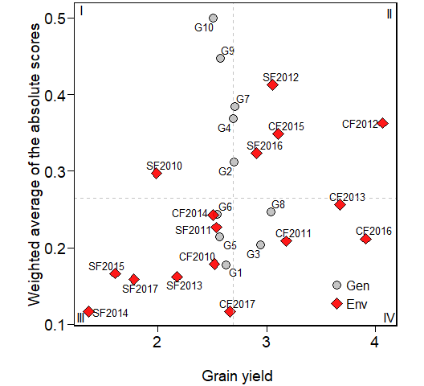

```r
plot.scores(WAAS1,
            type = 3)
```

The biplot above shows the coordinates of the genotypes and environments regarding the grain yield and the WAAS values. It is in fact the plot of the columns Y and WAAS from the above table. A detailed discussion on the interpretation of this biplot can be seen in section 6.2.3.